# Proyecto integrativo: visualización de datos de videojuegos

Autores/as

Emilio Ortiz-Avila

Mayela Fosado-Mendoza

Fecha de publicación

25 de junio de 2026

# Descripción general

En este proyecto construirás una página en Quarto con un análisis visual de una base de datos de ventas de videojuegos.

El objetivo no es llenar respuestas en este documento. El objetivo es desarrollar una página con resultados: código, tablas resumidas, gráficas e interpretaciones breves.

Cada sección de análisis debe incluir:

- Una frase breve que indique qué se quiere mostrar.
- El código necesario para preparar los datos.
- Una gráfica construida con `ggplot2`.
- Una interpretación corta debajo de la gráfica.

El flujo de trabajo será:

```
pregunta de análisis → preparación de datos → gráfica → interpretación
```

# Datos

Usaremos el archivo `vgsales.csv`, disponible en Kaggle como `Video Game Sales`.

Cada fila representa un videojuego. Algunas columnas importantes son:

| Columna | Descripción |
| --- | --- |
| `Rank` | Posición del videojuego dentro de la base |
| `Name` | Nombre del videojuego |
| `Platform` | Plataforma o consola |
| `Year` | Año de lanzamiento |
| `Genre` | Género del videojuego |
| `Publisher` | Compañía publicadora |
| `NA_Sales` | Ventas en Norteamérica |
| `EU_Sales` | Ventas en Europa |
| `JP_Sales` | Ventas en Japón |
| `Other_Sales` | Ventas en otras regiones |
| `Global_Sales` | Ventas globales |

Las ventas están reportadas en millones de copias.

# Crear el repositorio local

Crea una carpeta para tu proyecto e inicializa un repositorio local con Git.

```bash
mkdir video-game-sales-r
cd video-game-sales-r
git init
```

# Crear la estructura del proyecto

Dentro del repositorio, crea las carpetas necesarias.

```bash
mkdir data
mkdir scripts
mkdir figures
```

Crea los archivos principales.

```bash
touch README.md
touch ejercicio_videojuegos.qmd
touch scripts/01_analisis_videojuegos.R
```

Tu proyecto debe tener una estructura parecida a esta:

```
video-game-sales-r/
├── data/
│   └── vgsales.csv
├── scripts/
│   └── 01_analisis_videojuegos.R
├── figures/
│   ├── grafica_01.png
│   ├── grafica_02.png
│   └── grafica_final.png
├── ejercicio_videojuegos.qmd
└── README.md
```

Los archivos de imagen se crearán cuando guardes tus gráficas.

# Descargar la base de datos

Si tienes configurada la herramienta de Kaggle en la terminal, puedes descargar la base de datos con:

```bash
pip install kaggle
```

```bash
kaggle datasets download -d gregorut/videogamesales -p data --unzip
```

Verifica que el archivo esté en la carpeta `data/`.

```bash
ls data
```

Debe aparecer el archivo:

```
vgsales.csv
```

Si la descarga no funciona, usa el archivo `vgsales.csv` proporcionado por las personas instructoras y colócalo dentro de la carpeta `data/`.

# Primer commit

Guarda la estructura inicial del proyecto.

```bash
git status
git add .
git commit -m "Crea estructura inicial del proyecto"
```

# Preparar el entorno en R

En el archivo `ejercicio_videojuegos.qmd`, carga los paquetes necesarios.

```r
library(readr)
library(dplyr)
library(ggplot2)
library(tidyr)
library(forcats)
```

Importa los datos.

```r
videojuegos <- read_csv("data/vgsales.csv", show_col_types = FALSE)
```

# Exploración inicial

Antes de analizar, revisa la estructura de la base de datos.

```r
head(videojuegos)
```

```
# A tibble: 6 × 11
   Rank Name           Platform Year  Genre Publisher NA_Sales EU_Sales JP_Sales
  <dbl> <chr>          <chr>    <chr> <chr> <chr>        <dbl>    <dbl>    <dbl>
1     1 Wii Sports     Wii      2006  Spor… Nintendo      41.5    29.0      3.77
2     2 Super Mario B… NES      1985  Plat… Nintendo      29.1     3.58     6.81
3     3 Mario Kart Wii Wii      2008  Raci… Nintendo      15.8    12.9      3.79
4     4 Wii Sports Re… Wii      2009  Spor… Nintendo      15.8    11.0      3.28
5     5 Pokemon Red/P… GB       1996  Role… Nintendo      11.3     8.89    10.2
6     6 Tetris         GB       1989  Puzz… Nintendo      23.2     2.26     4.22
# ℹ 2 more variables: Other_Sales <dbl>, Global_Sales <dbl>
```

```r
dim(videojuegos)
```

```
[1] 16598    11
```

```r
names(videojuegos)
```

```
 [1] "Rank"         "Name"         "Platform"     "Year"         "Genre"
 [6] "Publisher"    "NA_Sales"     "EU_Sales"     "JP_Sales"     "Other_Sales"
[11] "Global_Sales"
```

```r
glimpse(videojuegos)
```

```
Rows: 16,598
Columns: 11
$ Rank         <dbl> 1, 2, 3, 4, 5, 6, 7, 8, 9, 10, 11, 12, 13, 14, 15, 16, 17…
$ Name         <chr> "Wii Sports", "Super Mario Bros.", "Mario Kart Wii", "Wii…
$ Platform     <chr> "Wii", "NES", "Wii", "Wii", "GB", "GB", "DS", "Wii", "Wii…
$ Year         <chr> "2006", "1985", "2008", "2009", "1996", "1989", "2006", "…
$ Genre        <chr> "Sports", "Platform", "Racing", "Sports", "Role-Playing",…
$ Publisher    <chr> "Nintendo", "Nintendo", "Nintendo", "Nintendo", "Nintendo…
$ NA_Sales     <dbl> 41.49, 29.08, 15.85, 15.75, 11.27, 23.20, 11.38, 14.03, 1…
$ EU_Sales     <dbl> 29.02, 3.58, 12.88, 11.01, 8.89, 2.26, 9.23, 9.20, 7.06, …
$ JP_Sales     <dbl> 3.77, 6.81, 3.79, 3.28, 10.22, 4.22, 6.50, 2.93, 4.70, 0.…
$ Other_Sales  <dbl> 8.46, 0.77, 3.31, 2.96, 1.00, 0.58, 2.90, 2.85, 2.26, 0.4…
$ Global_Sales <dbl> 82.74, 40.24, 35.82, 33.00, 31.37, 30.26, 30.01, 29.02, 2…
```

En tu página, incluye un párrafo breve que explique:

- Qué representa cada fila.
- Cuántas observaciones y columnas tiene la base.
- Qué variable usarás como medida principal de ventas.

# Limpieza básica

Revisa valores faltantes.

```r
colSums(is.na(videojuegos))
```

```
        Rank         Name     Platform         Year        Genre    Publisher
           0            0            0            0            0            0
    NA_Sales     EU_Sales     JP_Sales  Other_Sales Global_Sales
           0            0            0            0            0
```

Revisa el tipo de dato de la columna `Year`.

```r
class(videojuegos$Year)
```

```
[1] "character"
```

Convierte `Year` a número y elimina registros sin año o sin publicadora.

```r
videojuegos_limpio <- videojuegos %>%
  mutate(
    Year = readr::parse_number(as.character(Year))
  ) %>%
  filter(!is.na(Year)) %>%
  filter(!is.na(Publisher))
```

Compara la base original con la base limpia.

```r
dim(videojuegos)
```

```
[1] 16598    11
```

```r
dim(videojuegos_limpio)
```

```
[1] 16327    11
```

Verifica que `Year` ya sea numérica.

```r
class(videojuegos_limpio$Year)
```

```
[1] "numeric"
```

En tu página, incluye una nota breve sobre qué limpieza hiciste y por qué.

# Tema visual

Usa este tema para dar consistencia visual a tus gráficas.

```r
theme_videojuegos <- function() {
  theme_minimal(base_size = 13) +
    theme(
      plot.title = element_text(face = "bold", size = 16),
      plot.subtitle = element_text(size = 11),
      plot.caption = element_text(size = 9, color = "#659287"),
      axis.title = element_text(face = "bold"),
      panel.grid.minor = element_blank(),
      legend.position = "bottom"
    )
}
```

# Criterios para las gráficas

Cada gráfica debe cumplir con lo siguiente:

- Responder una pregunta clara.
- Tener un título informativo.
- Tener subtítulo cuando ayude a entender la comparación.
- Mostrar ejes con nombres claros.
- Incluir unidades cuando sea necesario.
- Ordenar categorías cuando corresponda.
- Evitar demasiadas categorías.
- Usar un diseño limpio.
- Incluir una interpretación breve.

# Ejercicio 1. Videojuegos con mayores ventas globales

Construye una visualización que muestre los 10 videojuegos con mayores ventas globales.

Prepara los datos:

```r
top_juegos <- videojuegos_limpio %>%
  select(Name, Platform, Year, Genre, Publisher, Global_Sales) %>%
  arrange(desc(Global_Sales)) %>%
  slice_head(n = 10)

top_juegos
```

```
# A tibble: 10 × 6
   Name                      Platform  Year Genre        Publisher Global_Sales
   <chr>                     <chr>    <dbl> <chr>        <chr>            <dbl>
 1 Wii Sports                Wii       2006 Sports       Nintendo          82.7
 2 Super Mario Bros.         NES       1985 Platform     Nintendo          40.2
 3 Mario Kart Wii            Wii       2008 Racing       Nintendo          35.8
 4 Wii Sports Resort         Wii       2009 Sports       Nintendo          33
 5 Pokemon Red/Pokemon Blue  GB        1996 Role-Playing Nintendo          31.4
 6 Tetris                    GB        1989 Puzzle       Nintendo          30.3
 7 New Super Mario Bros.     DS        2006 Platform     Nintendo          30.0
 8 Wii Play                  Wii       2006 Misc         Nintendo          29.0
 9 New Super Mario Bros. Wii Wii       2009 Platform     Nintendo          28.6
10 Duck Hunt                 NES       1984 Shooter      Nintendo          28.3
```

En tu página, incluye una gráfica que represente estos datos.

Requisitos de la gráfica:

- Debe mostrar los nombres de los videojuegos.
- Debe mostrar las ventas globales.
- Debe estar ordenada de menor a mayor o de mayor a menor.
- Debe ser fácil de leer.

Debajo de la gráfica, escribe una interpretación corta.

**Ver gráfica**

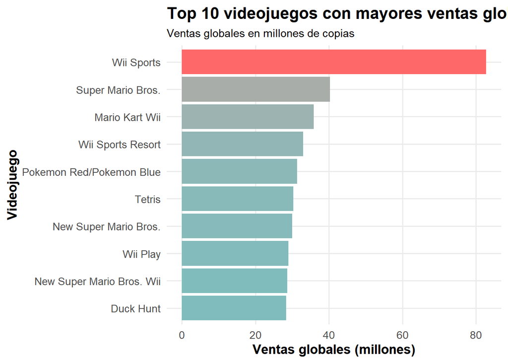

```r
top_juegos %>%
  mutate(Name = reorder(Name, Global_Sales)) %>%
  ggplot(aes(x = Name, y = Global_Sales, fill = Global_Sales)) +
  geom_col() +
  coord_flip() +
  scale_fill_gradient(
    low = "#80BCBD",
    high = "#FF6868"
  ) +
  labs(
    title = "Top 10 videojuegos con mayores ventas globales",
    subtitle = "Ventas globales en millones de copias",
    x = "Videojuego",
    y = "Ventas globales (millones)"
  ) +
  theme_videojuegos() +
  theme(legend.position = "none")
```

# Ejercicio 2. Ventas globales por género

Construye una visualización para comparar las ventas globales acumuladas por género.

Prepara los datos:

```r
ventas_por_genero <- videojuegos_limpio %>%
  group_by(Genre) %>%
  summarise(
    ventas_globales = sum(Global_Sales, na.rm = TRUE),
    numero_juegos = n(),
    .groups = "drop"
  ) %>%
  arrange(desc(ventas_globales))

ventas_por_genero
```

```
# A tibble: 12 × 3
   Genre        ventas_globales numero_juegos
   <chr>                  <dbl>         <int>
 1 Action                 1723.          3253
 2 Sports                 1309.          2304
 3 Shooter                1026.          1282
 4 Role-Playing            924.          1471
 5 Platform                829.           876
 6 Misc                    798.          1710
 7 Racing                  727.          1226
 8 Fighting                444.           836
 9 Simulation              390.           851
10 Puzzle                  242.           571
11 Adventure               235.          1276
12 Strategy                173.           671
```

En tu página, incluye una gráfica que muestre qué géneros concentran más ventas globales.

Requisitos de la gráfica:

- Debe comparar géneros.
- Debe usar ventas globales acumuladas.
- Debe ordenar los géneros.
- Debe comunicar si estás mostrando ventas totales, no ventas promedio.

Debajo de la gráfica, escribe una interpretación corta.

**Ver gráfica**

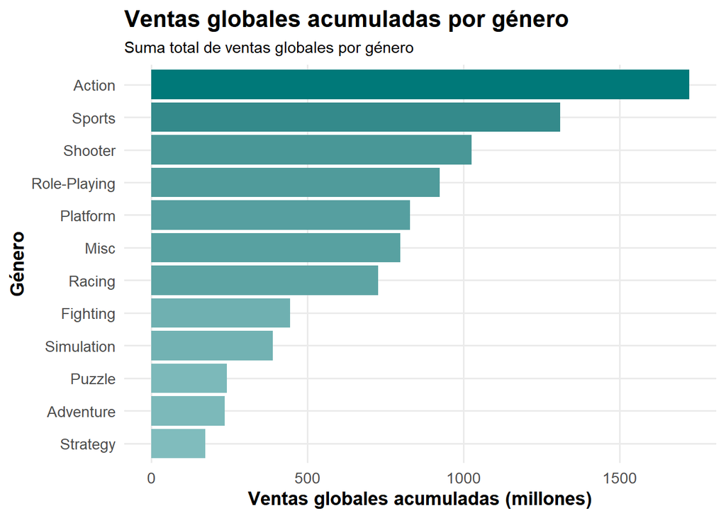

```r
ventas_por_genero %>%
  mutate(Genre = reorder(Genre, ventas_globales)) %>%
  ggplot(aes(
    x = Genre,
    y = ventas_globales,
    fill = ventas_globales
  )) +
  geom_col() +
  coord_flip() +
  scale_fill_gradient(
    low = "#80BCBD",
    high = "#007979"
  ) +
  labs(
    title = "Ventas globales acumuladas por género",
    subtitle = "Suma total de ventas globales por género",
    x = "Género",
    y = "Ventas globales acumuladas (millones)"
  ) +
  theme_videojuegos() +
  theme(legend.position = "none")
```

# Ejercicio 3. Número de juegos y ventas globales

Construye una visualización para explorar si los géneros con más juegos registrados también acumulan más ventas.

Prepara los datos:

```r
genero_juegos_ventas <- videojuegos_limpio %>%
  group_by(Genre) %>%
  summarise(
    numero_juegos = n(),
    ventas_globales = sum(Global_Sales, na.rm = TRUE),
    .groups = "drop"
  )

genero_juegos_ventas
```

```
# A tibble: 12 × 3
   Genre        numero_juegos ventas_globales
   <chr>                <int>           <dbl>
 1 Action                3253           1723.
 2 Adventure             1276            235.
 3 Fighting               836            444.
 4 Misc                  1710            798.
 5 Platform               876            829.
 6 Puzzle                 571            242.
 7 Racing                1226            727.
 8 Role-Playing          1471            924.
 9 Shooter               1282           1026.
10 Simulation             851            390.
11 Sports                2304           1309.
12 Strategy               671            173.
```

En tu página, incluye una gráfica que compare `numero_juegos` y `ventas_globales`.

Requisitos de la gráfica:

- Debe mostrar la relación entre ambas variables.
- Cada punto o marca debe representar un género.
- Debe permitir identificar si hay géneros que no siguen el patrón general.

Debajo de la gráfica, escribe una interpretación corta.

**Ver gráfica**

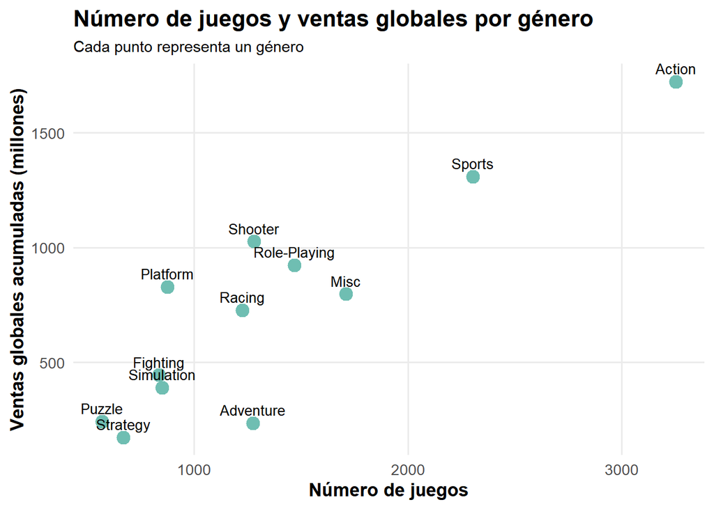

```r
ggplot(
  genero_juegos_ventas,
  aes(
    x = numero_juegos,
    y = ventas_globales,
    label = Genre
  )
) +
  geom_point(
    color = "#6FBEB2",
    size = 4
  ) +
  geom_text(
    vjust = -0.7,
    size = 3.5
  ) +
  labs(
    title = "Número de juegos y ventas globales por género",
    subtitle = "Cada punto representa un género",
    x = "Número de juegos",
    y = "Ventas globales acumuladas (millones)"
  ) +
  theme_videojuegos()
```

# Ejercicio 4. Venta típica por género

Construye una visualización que muestre la venta mediana por género.

Prepara los datos:

```r
ventas_tipicas_genero <- videojuegos_limpio %>%
  group_by(Genre) %>%
  summarise(
    venta_promedio = mean(Global_Sales, na.rm = TRUE),
    venta_mediana = median(Global_Sales, na.rm = TRUE),
    numero_juegos = n(),
    .groups = "drop"
  ) %>%
  arrange(desc(venta_mediana))

ventas_tipicas_genero
```

```
# A tibble: 12 × 4
   Genre        venta_promedio venta_mediana numero_juegos
   <chr>                 <dbl>         <dbl>         <int>
 1 Platform              0.947          0.28           876
 2 Shooter               0.800          0.23          1282
 3 Sports                0.568          0.22          2304
 4 Fighting              0.531          0.21           836
 5 Action                0.530          0.19          3253
 6 Racing                0.593          0.19          1226
 7 Role-Playing          0.628          0.19          1471
 8 Misc                  0.466          0.16          1710
 9 Simulation            0.458          0.16           851
10 Puzzle                0.424          0.1            571
11 Strategy              0.258          0.09           671
12 Adventure             0.184          0.06          1276
```

En tu página, incluye una gráfica que represente `venta_mediana` por género.

Requisitos de la gráfica:

- Debe mostrar venta mediana, no venta total.
- Debe ordenar los géneros.
- Debe explicar en el título o subtítulo que se usa la mediana.

Debajo de la gráfica, escribe una interpretación corta.

**Ver gráfica**

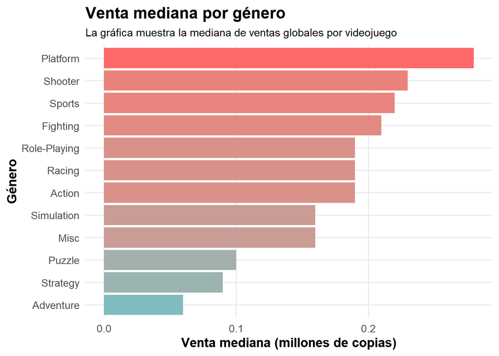

```r
ventas_tipicas_genero %>%
  mutate(Genre = reorder(Genre, venta_mediana)) %>%
  ggplot(aes(
    x = Genre,
    y = venta_mediana,
    fill = venta_mediana
  )) +
  geom_col() +
  coord_flip() +
  scale_fill_gradient(
   low = "#80BCBD",
    high = "#FF6868"
  ) +
  labs(
    title = "Venta mediana por género",
    subtitle = "La gráfica muestra la mediana de ventas globales por videojuego",
    x = "Género",
    y = "Venta mediana (millones de copias)"
  ) +
  theme_videojuegos() +
  theme(legend.position = "none")
```

# Ejercicio 5. Ventas por región

Construye una visualización que compare ventas acumuladas por región.

Prepara los datos:

```r
ventas_por_region <- videojuegos_limpio %>%
  summarise(
    Norteamerica = sum(NA_Sales, na.rm = TRUE),
    Europa = sum(EU_Sales, na.rm = TRUE),
    Japon = sum(JP_Sales, na.rm = TRUE),
    Otras_regiones = sum(Other_Sales, na.rm = TRUE)
  ) %>%
  pivot_longer(
    cols = everything(),
    names_to = "region",
    values_to = "ventas"
  ) %>%
  arrange(desc(ventas))

ventas_por_region
```

```
# A tibble: 4 × 2
  region         ventas
  <chr>           <dbl>
1 Norteamerica    4333.
2 Europa          2409.
3 Japon           1284.
4 Otras_regiones   789.
```

En tu página, incluye una gráfica que represente las ventas por región.

Requisitos de la gráfica:

- Debe comparar regiones.
- Debe usar ventas acumuladas.
- Debe estar ordenada.
- Debe evitar afirmar que una región “juega más” sin evidencia adicional.

Debajo de la gráfica, escribe una interpretación corta.

**Ver gráfica**

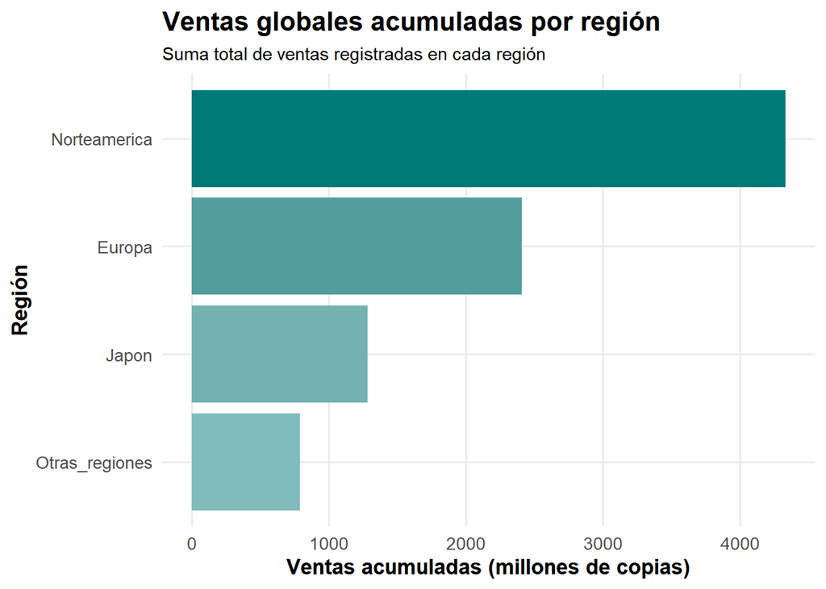

```r
ventas_por_region %>%
  mutate(region = reorder(region, ventas)) %>%
  ggplot(aes(
    x = region,
    y = ventas,
    fill = ventas
  )) +
  geom_col() +
  coord_flip() +
  scale_fill_gradient(
   low = "#80BCBD",
    high = "#007979"
  ) +
  labs(
    title = "Ventas globales acumuladas por región",
    subtitle = "Suma total de ventas registradas en cada región",
    x = "Región",
    y = "Ventas acumuladas (millones de copias)"
  ) +
  theme_videojuegos() +
  theme(legend.position = "none")
```

# Ejercicio 6. Ventas globales por década

Construye una visualización que muestre cómo se distribuyen las ventas globales por década.

Primero crea una columna llamada `decada`.

```r
videojuegos_limpio <- videojuegos_limpio %>%
  mutate(decada = floor(Year / 10) * 10)
```

Prepara los datos:

```r
ventas_por_decada <- videojuegos_limpio %>%
  group_by(decada) %>%
  summarise(
    ventas_globales = sum(Global_Sales, na.rm = TRUE),
    numero_juegos = n(),
    .groups = "drop"
  ) %>%
  arrange(decada)

ventas_por_decada
```

```
# A tibble: 5 × 3
  decada ventas_globales numero_juegos
   <dbl>           <dbl>         <int>
1   1980          377.             205
2   1990         1279.            1769
3   2000         4644.            9208
4   2010         2521.            5144
5   2020            0.29             1
```

En tu página, incluye una gráfica que represente las ventas por década.

Requisitos de la gráfica:

- Debe mostrar el cambio temporal o la comparación entre décadas.
- Debe indicar que las ventas son acumuladas.
- Debe evitar conclusiones demasiado fuertes si la base no cubre todos los años por igual.

Debajo de la gráfica, escribe una interpretación corta.

**Ver gráfica**

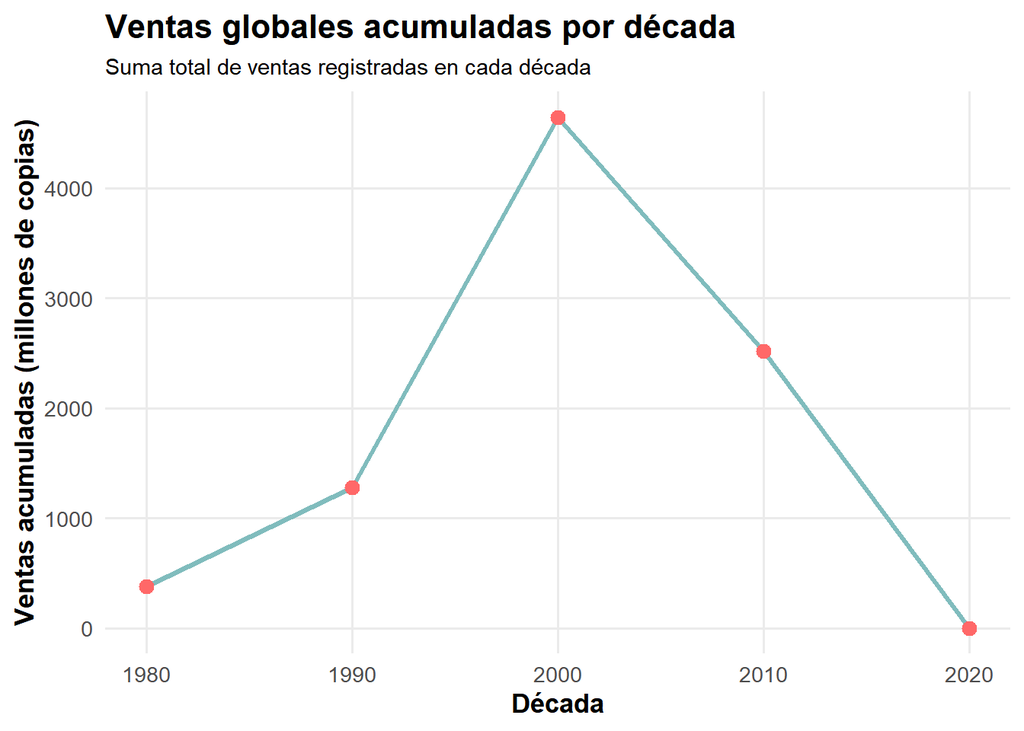

```r
ggplot(
  ventas_por_decada,
  aes(
    x = decada,
    y = ventas_globales
  )
) +
  geom_line(
    color = "#80BCBD",
    linewidth = 1.2
  ) +
  geom_point(
    color = "#FF6868",
    size = 3
  ) +
  labs(
    title = "Ventas globales acumuladas por década",
    subtitle = "Suma total de ventas registradas en cada década",
    x = "Década",
    y = "Ventas acumuladas (millones de copias)"
  ) +
  theme_videojuegos()
```